# Exploratory Data Analysis Example

# Scenario

## A self-insured company wants to identify if providing managed care to their employees and covered dependents improves the overall health of their covered members.

- Without the availability of clinical notes from the hospitals to capture actual health outcomes, they use a proxy to aim at capturing the overall health as the total amount of billed charges from hospital, office, urgent, and emergency room visits.
- The company provides 2016 - 2018 data grouped by individual by year and includes various demographic indicators, frequency of visits to health practitioners, number of diseases, count of pharmacy scrips and if the patient was diagnosed with a serious disease in the indicated year.

  30 features are: year, CGI, Age, isMale, MM, Employee, Spouse, Admission, ALOS, ERVisit, OutERVisit, OV, LongOV, UrgentCare, NumDis, NumChronic, NumAcute, NumScripts, Billed, Cancer, Type2, Type1, Hypertension, CAD, CHF, Cerebro, RenalFail, MajorTrauma, Premature, Transplant
  - 2016 should have 52,353 records
  - 2017 should have 54,124 records
  - 2018 should have 56,956 records
- To identify the validity of managed care, they also have access to the number of ‘Care Gaps’ the members had over the course of the year, which they define as the number of times an individual does not meet clinical guidelines for care based on his/her diagnosed diseases or for preventive care.

  CGI feature in the data

## Read the data

```r
df <- read_csv('finaldata.csv') %>%
  mutate(rn = row_number()) %>%
  select(rn, everything())
```

## Check the head and tail

```r
# # check the head
kable(head(df))
```

| rn | year | CGI | Age | isMale | MM | Employee | Spouse | Admission | ALOS | ERVisit | OutERVisit | OV | LongOV | UrgentCare | NumDis | NumChronic | NumAcute | Billed | Cancer | Type2 | Type1 | Hypertension | CAD | CHF | Cerebro | RenalFail | MajorTrauma | Premature | Transplant |
| --- | --- | --- | --- | --- | --- | --- | --- | --- | --- | --- | --- | --- | --- | --- | --- | --- | --- | --- | --- | --- | --- | --- | --- | --- | --- | --- | --- | --- | --- |
| 1 | 2018 | 9 | 20 | 1 | 12 | 0 | 0 | 1 | 329 | 1 | 0 | 5 | 1 | 0 | 4 | 2 | 2 | 3175651 | 0 | 0 | 0 | 0 | 0 | 1 | 0 | 0 | 1 | 0 | 0 |
| 2 | 2018 | 2 | 64 | 1 | 6 | 1 | 0 | 1 | 92 | 2 | 2 | 7 | 0 | 0 | 7 | 7 | 0 | 2053580 | 0 | 1 | 0 | 0 | 1 | 1 | 0 | 1 | 0 | 0 | 0 |
| 3 | 2018 | 19 | 62 | 1 | 12 | 0 | 1 | 2 | 7 | 2 | 0 | 33 | 1 | 0 | 5 | 4 | 1 | 1592552 | 1 | 1 | 0 | 1 | 0 | 0 | 0 | 1 | 0 | 0 | 0 |
| 4 | 2018 | 2 | 58 | 0 | 12 | 0 | 1 | 0 | 0 | 0 | 0 | 19 | 1 | 0 | 1 | 0 | 1 | 1631335 | 0 | 0 | 0 | 0 | 0 | 0 | 0 | 0 | 0 | 0 | 0 |
| 5 | 2018 | 2 | 61 | 1 | 12 | 1 | 0 | 2 | 63 | 1 | 0 | 4 | 0 | 0 | 4 | 3 | 1 | 1270750 | 0 | 1 | 0 | 0 | 1 | 0 | 0 | 0 | 0 | 0 | 0 |
| 6 | 2018 | 2 | 55 | 1 | 12 | 0 | 1 | 2 | 19 | 2 | 0 | 16 | 1 | 0 | 9 | 4 | 5 | 1563299 | 0 | 0 | 0 | 0 | 1 | 1 | 1 | 1 | 1 | 0 | 0 |

```r
# # check the tail
kable(tail(df))
```

| rn | year | CGI | Age | isMale | MM | Employee | Spouse | Admission | ALOS | ERVisit | OutERVisit | OV | LongOV | UrgentCare | NumDis | NumChronic | NumAcute | Billed | Cancer | Type2 | Type1 | Hypertension | CAD | CHF | Cerebro | RenalFail | MajorTrauma | Premature | Transplant |
| --- | --- | --- | --- | --- | --- | --- | --- | --- | --- | --- | --- | --- | --- | --- | --- | --- | --- | --- | --- | --- | --- | --- | --- | --- | --- | --- | --- | --- | --- |
| 56951 | 2018 | 0 | 29 | 1 | 4 | 1 | 0 | 0 | 0 | 0 | 0 | 0 | 0 | 0 | 0 | 0 | 0 | 0 | 0 | 0 | 0 | 0 | 0 | 0 | 0 | 0 | 0 | 0 | 0 |
| 56952 | 2018 | 0 | 44 | 1 | 12 | 1 | 0 | 0 | 0 | 0 | 0 | 0 | 1 | 0 | 0 | 0 | 0 | 0 | 0 | 0 | 0 | 0 | 0 | 0 | 0 | 0 | 0 | 0 | 0 |
| 56953 | 2018 | 1 | 36 | 0 | 12 | 1 | 0 | 0 | 0 | 0 | 0 | 0 | 0 | 0 | 0 | 0 | 0 | 0 | 0 | 0 | 0 | 0 | 0 | 0 | 0 | 0 | 0 | 0 | 0 |
| 56954 | 2018 | 0 | 24 | 1 | 12 | 0 | 0 | 0 | 0 | 0 | 0 | 1 | 0 | 0 | 0 | 0 | 0 | 150 | 0 | 0 | 0 | 0 | 0 | 0 | 0 | 0 | 0 | 0 | 0 |
| 56955 | 2018 | 0 | 21 | 0 | 4 | 0 | 0 | 0 | 0 | 0 | 0 | 0 | 0 | 0 | 0 | 0 | 0 | 0 | 0 | 0 | 0 | 0 | 0 | 0 | 0 | 0 | 0 | 0 | 0 |
| 56956 | 2018 | 4 | 55 | 0 | 12 | 0 | 1 | 0 | 0 | 0 | 0 | 0 | 0 | 0 | 0 | 0 | 0 | 0 | 0 | 0 | 0 | 0 | 0 | 0 | 0 | 0 | 0 | 0 | 0 |

In reviewing the head and tail of the data I’m only seeing 2018. The total number of rows is also only 56,956, which was the number indicated as the total for 2018.

Check to make sure the other years are missing

```r
df %>% group_by(year) %>% summarise(rows = n())
```

```
## # A tibble: 1 x 2
##    year  rows
##   <dbl> <int>
## 1  2018 56956
```

Verified only 2018 is present.

**Need to check with data provider for 2016 and 2017 data**

## Count the columns

```r
ncol(df)
```

```
## [1] 30
```

There are 30 columns, but there should be 31 (30 original + 1 added for row number).

The current column names are rn, year, CGI, Age, isMale, MM, Employee, Spouse, Admission, ALOS, ERVisit, OutERVisit, OV, LongOV, UrgentCare, NumDis, NumChronic, NumAcute, Billed, Cancer, Type2, Type1, Hypertension, CAD, CHF, Cerebro, RenalFail, MajorTrauma, Premature, Transplant.

Looks like NumScripts is missing; **follow up with data provider**

## Check the structure of the data

```r
# # structure
str(df)
```

```
## Classes 'spec_tbl_df', 'tbl_df', 'tbl' and 'data.frame': 56956 obs. of  30 variables:
##  $ rn          : int  1 2 3 4 5 6 7 8 9 10 ...
##  $ year        : num  2018 2018 2018 2018 2018 ...
##  $ CGI         : num  9 2 19 2 2 2 2 5 0 3 ...
##  $ Age         : num  20 64 62 58 61 55 8 64 43 44 ...
##  $ isMale      : num  1 1 1 0 1 1 0 0 1 1 ...
##  $ MM          : num  12 6 12 12 12 12 12 12 12 12 ...
##  $ Employee    : num  0 1 0 0 1 0 0 1 0 1 ...
##  $ Spouse      : num  0 0 1 1 0 1 NA 0 1 0 ...
##  $ Admission   : num  1 1 2 0 2 2 20 3 0 4 ...
##  $ ALOS        : num  329 92 7 0 63 19 3 26 0 3 ...
##  $ ERVisit     : num  1 2 2 0 1 2 6 1 0 0 ...
##  $ OutERVisit  : num  0 2 0 0 0 0 2 1 0 0 ...
##  $ OV          : num  5 7 33 19 4 16 40 41 8 8 ...
##  $ LongOV      : num  1 0 1 1 0 1 1 1 1 1 ...
```

[output cut: 16 more lines]

## Check the summary of each variable

```r
# # summary
summary(df)
```

```
##        rn             year           CGI              Age
##  Min.   :    1   Min.   :2018   Min.   : 0.000   Min.   : 0.00
##  1st Qu.:14240   1st Qu.:2018   1st Qu.: 0.000   1st Qu.:21.00
##  Median :28478   Median :2018   Median : 0.000   Median :36.00
##  Mean   :28478   Mean   :2018   Mean   : 1.238   Mean   :34.83
##  3rd Qu.:42717   3rd Qu.:2018   3rd Qu.: 2.000   3rd Qu.:49.00
##  Max.   :56956   Max.   :2018   Max.   :19.000   Max.   :95.00
##
##      isMale             MM            Employee          Spouse
##  Min.   :0.0000   Min.   : 0.000   Min.   :0.0000   Min.   :0.000
##  1st Qu.:0.0000   1st Qu.: 8.000   1st Qu.:0.0000   1st Qu.:0.000
##  Median :0.0000   Median :12.000   Median :1.0000   Median :0.000
##  Mean   :0.4878   Mean   : 9.782   Mean   :0.5401   Mean   :0.189
##  3rd Qu.:1.0000   3rd Qu.:12.000   3rd Qu.:1.0000   3rd Qu.:0.000
##  Max.   :1.0000   Max.   :13.000   Max.   :1.0000   Max.   :1.000
##                                                     NA's   :11975
##    Admission             ALOS             ERVisit         OutERVisit
##  Min.   : 0.00000   Min.   :  0.0000   Min.   : 0.000   Min.   : 0.0000
##  1st Qu.: 0.00000   1st Qu.:  0.0000   1st Qu.: 0.000   1st Qu.: 0.0000
##  Median : 0.00000   Median :  0.0000   Median : 0.000   Median : 0.0000
##  Mean   : 0.04172   Mean   :  0.1494   Mean   : 0.154   Mean   : 0.1367
##  3rd Qu.: 0.00000   3rd Qu.:  0.0000   3rd Qu.: 0.000   3rd Qu.: 0.0000
##  Max.   :20.00000   Max.   :329.0000   Max.   :24.000   Max.   :24.0000
##
##        OV              LongOV         UrgentCare          NumDis
##  Min.   :  0.000   Min.   :0.0000   Min.   : 0.0000   Min.   : 0.00
##  1st Qu.:  0.000   1st Qu.:0.0000   1st Qu.: 0.0000   1st Qu.: 0.00
##  Median :  2.000   Median :1.0000   Median : 0.0000   Median : 0.00
##  Mean   :  3.552   Mean   :0.5778   Mean   : 0.1216   Mean   : 0.52
##  3rd Qu.:  5.000   3rd Qu.:1.0000   3rd Qu.: 0.0000   3rd Qu.: 1.00
##  Max.   :618.000   Max.   :1.0000   Max.   :41.0000   Max.   :12.00
##
##    NumChronic         NumAcute          Billed            Cancer
##  Min.   : 0.0000   Min.   :0.0000   Min.   :  -9791   Min.   :0.0000
##  1st Qu.: 0.0000   1st Qu.:0.0000   1st Qu.:    244   1st Qu.:0.0000
##  Median : 0.0000   Median :0.0000   Median :   1388   Median :0.0000
##  Mean   : 0.3705   Mean   :0.1494   Mean   :   7582   Mean   :0.0036
##  3rd Qu.: 0.0000   3rd Qu.:0.0000   3rd Qu.:   4782   3rd Qu.:0.0000
##  Max.   :10.0000   Max.   :6.0000   Max.   :3175651   Max.   :1.0000
##                                                       NA's   :1072
```

[output cut: 9 more lines]

```
##  Min.   :0.000000   Min.   :0.000000   Min.   :0.000000
##  1st Qu.:0.000000   1st Qu.:0.000000   1st Qu.:0.000000
##  Median :0.000000   Median :0.000000   Median :0.000000
##  Mean   :0.001317   Mean   :0.001949   Mean   :0.001053
##  3rd Qu.:0.000000   3rd Qu.:0.000000   3rd Qu.:0.000000
##  Max.   :1.000000   Max.   :1.000000   Max.   :1.000000
##
##   MajorTrauma         Premature           Transplant
##  Min.   :0.000000   Min.   :0.0000000   Min.   :0.0000000
##  1st Qu.:0.000000   1st Qu.:0.0000000   1st Qu.:0.0000000
##  Median :0.000000   Median :0.0000000   Median :0.0000000
##  Mean   :0.001334   Mean   :0.0002809   Mean   :0.0005267
##  3rd Qu.:0.000000   3rd Qu.:0.0000000   3rd Qu.:0.0000000
##  Max.   :1.000000   Max.   :1.0000000   Max.   :1.0000000
##
```

Just skimming through the structure I see one NA in Spouse, but the data formatted as numbers makes sense as the descriptive variables are already coded to binary.

## Check the missing values

```r
# # identify variables with missing data
df %>%
  select_if(function(x) any(is.na(x))) %>%
  summarise_each(funs(sum(is.na(.))))
```

```
## # A tibble: 1 x 4
##   Spouse Cancer Type2 Type1
##    <int>  <int> <int> <int>
## 1  11975   1072  1072  1072
```

`Spouse` has 11,975 NAs. `Cancer`, `Type1`, and `Type2` each have 1,072.

To try to determine if there’s any similarities across the missing variables, I’ll try to compare against the two demographic variables available - `Age` and `isMale`.

```r
# # baseline for comparison
baseline <- summary(df %>%
          select(Age, isMale))

print(baseline)
```

```
##       Age            isMale
##  Min.   : 0.00   Min.   :0.0000
##  1st Qu.:21.00   1st Qu.:0.0000
##  Median :36.00   Median :0.0000
##  Mean   :34.83   Mean   :0.4878
##  3rd Qu.:49.00   3rd Qu.:1.0000
##  Max.   :95.00   Max.   :1.0000
```

```r
# # for missing Spouse variable
summary(df %>%
          filter(is.na(Spouse)) %>%
          select(Age, isMale))
```

```
##       Age             isMale
##  Min.   : 0.000   Min.   :0.0000
##  1st Qu.: 5.000   1st Qu.:0.0000
##  Median : 9.000   Median :1.0000
##  Mean   : 9.185   Mean   :0.5121
##  3rd Qu.:13.000   3rd Qu.:1.0000
##  Max.   :17.000   Max.   :1.0000
```

Follow up with data provider to verify there are no spouses under 18

```r
# # recode Spouse to 0 when 17 or less
df %<>%
  mutate(Spouse = case_when(Age<=17 ~ 0,
                            TRUE ~ Spouse))
```

```r
print(baseline)
```

```
##       Age            isMale
##  Min.   : 0.00   Min.   :0.0000
##  1st Qu.:21.00   1st Qu.:0.0000
##  Median :36.00   Median :0.0000
##  Mean   :34.83   Mean   :0.4878
##  3rd Qu.:49.00   3rd Qu.:1.0000
##  Max.   :95.00   Max.   :1.0000
```

```r
# # for missing Cancer variable
summary(df %>%
          filter(is.na(Cancer)) %>%
          select(Age, isMale))
```

```
##       Age         isMale
##  Min.   :33   Min.   :0.000
##  1st Qu.:33   1st Qu.:0.000
##  Median :33   Median :0.000
##  Mean   :33   Mean   :0.459
##  3rd Qu.:33   3rd Qu.:1.000
##  Max.   :33   Max.   :1.000
```

`Cancer` looks to be missing for only those members who are 33 years old. This also seems to be MNAR; however, it it may just be that the coding was missed. If the provider doesn’t have this available, we’ll have to go down the route of researching potential imputation methods.

Follow up with the data provider to verify their raw data is blank.

Possibly align with an external data science to check distribution of Cancer prevalance for 33 year olds and sample at random?? Likely risky; more research would be need into the repercussions

```r
print(baseline)
```

```
##       Age            isMale
##  Min.   : 0.00   Min.   :0.0000
##  1st Qu.:21.00   1st Qu.:0.0000
##  Median :36.00   Median :0.0000
##  Mean   :34.83   Mean   :0.4878
##  3rd Qu.:49.00   3rd Qu.:1.0000
##  Max.   :95.00   Max.   :1.0000
```

```r
# # for missing Type1 variable
summary(df %>%
          filter(is.na(Type1)) %>%
          select(Age, isMale))
```

```
##       Age         isMale
##  Min.   :33   Min.   :0.000
##  1st Qu.:33   1st Qu.:0.000
##  Median :33   Median :0.000
##  Mean   :33   Mean   :0.459
##  3rd Qu.:33   3rd Qu.:1.000
##  Max.   :33   Max.   :1.000
```

`Type1` looks to be the same as `Cancer.`

Follow up with data provider

```r
print(baseline)
```

```
##       Age            isMale
##  Min.   : 0.00   Min.   :0.0000
##  1st Qu.:21.00   1st Qu.:0.0000
##  Median :36.00   Median :0.0000
##  Mean   :34.83   Mean   :0.4878
##  3rd Qu.:49.00   3rd Qu.:1.0000
##  Max.   :95.00   Max.   :1.0000
```

```r
# # for missing Type2 variable
summary(df %>% filter(is.na(Type2)) %>%
          select(Age, isMale))
```

```
##       Age         isMale
##  Min.   :33   Min.   :0.000
##  1st Qu.:33   1st Qu.:0.000
##  Median :33   Median :0.000
##  Mean   :33   Mean   :0.459
##  3rd Qu.:33   3rd Qu.:1.000
##  Max.   :33   Max.   :1.000
```

`Type2` also looks to be the same as `Cancer.`

Follow up with data provider

## Check distributions and look for outliers

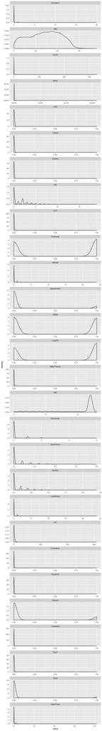

```r
df %>% select(-rn, -year) %>%
  tidyr::gather(var, value) %>%
  ggplot(aes(value)) +
  geom_density() +
  facet_wrap(~var, scales='free', ncol=1)
```

Most of these variables look very, very right skewed. Boxplots may show more information:

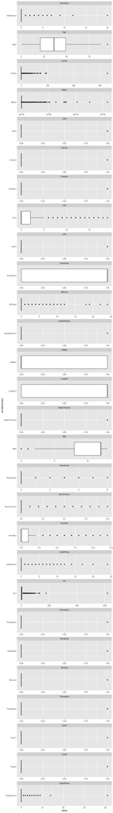

```r
df %>%
  select(-rn, -year) %>%
  tidyr::gather(var, value) %>%
  ggplot(aes(x=as.factor(var), y=value)) +
  geom_boxplot() +
  coord_flip() +
  facet_wrap(~var, scales='free', ncol=1)
```

There are quite a bit of outliers, so we may need to research these to identify how to handle.

## Try the easy solution first

The data provider hypothesizes that the number of Care Gaps an individual has will be directly predicting of the billed charges.

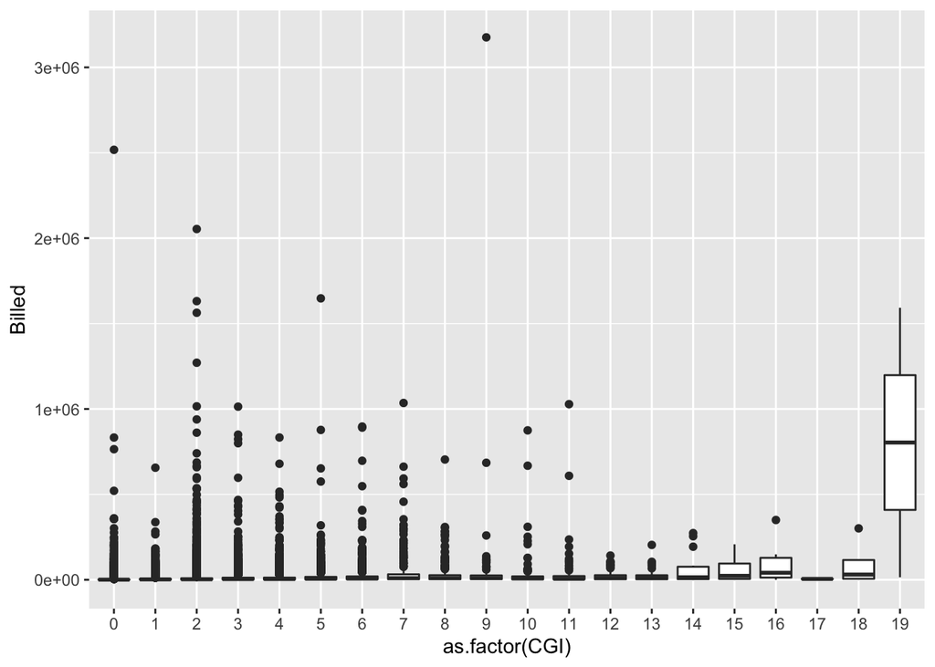

```r
df %>%
  select(CGI, Billed) %>%
  ggplot(aes(x=as.factor(CGI), y=Billed)) +
  geom_boxplot()
```

## Check all variables for potential collinearities

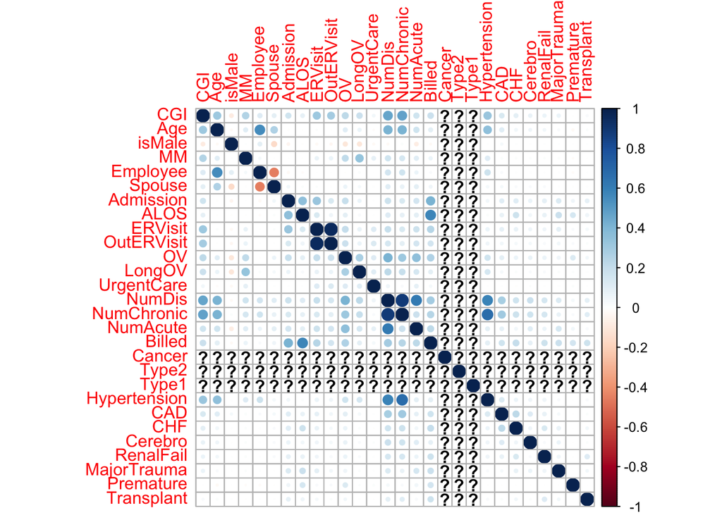

```r
df %>%
  select(-rn, -year) %>%
  cor %>%
  corrplot
```